# Risk Factor Analysis

## Outcome Variable

**Outcome Variable:** ever_sstunted

## Predictor Variables

**Intervention Variable:** hhwealth_quart

**Adjustment Set:**

unadjusted

## Stratifying Variables

The analysis was stratified on these variable(s):

- agecat
- studyid
- country

## Data Summary

| agecat | studyid | country | hhwealth_quart | ever_sstunted | n_cell | n |
| --- | --- | --- | --- | --- | --- | --- |
| 0-24 months | ki0047075b-MAL-ED | BANGLADESH | Wealth Q4 | 0 | 54 | 242 |
| 0-24 months | ki0047075b-MAL-ED | BANGLADESH | Wealth Q4 | 1 | 7 | 242 |
| 0-24 months | ki0047075b-MAL-ED | BANGLADESH | Wealth Q1 | 0 | 48 | 242 |
| 0-24 months | ki0047075b-MAL-ED | BANGLADESH | Wealth Q1 | 1 | 12 | 242 |
| 0-24 months | ki0047075b-MAL-ED | BANGLADESH | Wealth Q2 | 0 | 38 | 242 |
| 0-24 months | ki0047075b-MAL-ED | BANGLADESH | Wealth Q2 | 1 | 23 | 242 |
| 0-24 months | ki0047075b-MAL-ED | BANGLADESH | Wealth Q3 | 0 | 49 | 242 |
| 0-24 months | ki0047075b-MAL-ED | BANGLADESH | Wealth Q3 | 1 | 11 | 242 |
| 0-24 months | ki0047075b-MAL-ED | BRAZIL | Wealth Q4 | 0 | 47 | 210 |
| 0-24 months | ki0047075b-MAL-ED | BRAZIL | Wealth Q4 | 1 | 6 | 210 |
| 0-24 months | ki0047075b-MAL-ED | BRAZIL | Wealth Q1 | 0 | 48 | 210 |
| 0-24 months | ki0047075b-MAL-ED | BRAZIL | Wealth Q1 | 1 | 5 | 210 |
| 0-24 months | ki0047075b-MAL-ED | BRAZIL | Wealth Q2 | 0 | 49 | 210 |
| 0-24 months | ki0047075b-MAL-ED | BRAZIL | Wealth Q2 | 1 | 4 | 210 |
| 0-24 months | ki0047075b-MAL-ED | BRAZIL | Wealth Q3 | 0 | 45 | 210 |
| 0-24 months | ki0047075b-MAL-ED | BRAZIL | Wealth Q3 | 1 | 6 | 210 |
| 0-24 months | ki0047075b-MAL-ED | INDIA | Wealth Q4 | 0 | 48 | 235 |
| 0-24 months | ki0047075b-MAL-ED | INDIA | Wealth Q4 | 1 | 11 | 235 |
| 0-24 months | ki0047075b-MAL-ED | INDIA | Wealth Q1 | 0 | 42 | 235 |
| 0-24 months | ki0047075b-MAL-ED | INDIA | Wealth Q1 | 1 | 18 | 235 |
| 0-24 months | ki0047075b-MAL-ED | INDIA | Wealth Q2 | 0 | 42 | 235 |
| 0-24 months | ki0047075b-MAL-ED | INDIA | Wealth Q2 | 1 | 16 | 235 |
| 0-24 months | ki0047075b-MAL-ED | INDIA | Wealth Q3 | 0 | 45 | 235 |
| 0-24 months | ki0047075b-MAL-ED | INDIA | Wealth Q3 | 1 | 13 | 235 |
| 0-24 months | ki0047075b-MAL-ED | NEPAL | Wealth Q4 | 0 | 52 | 236 |
| 0-24 months | ki0047075b-MAL-ED | NEPAL | Wealth Q4 | 1 | 7 | 236 |
| 0-24 months | ki0047075b-MAL-ED | NEPAL | Wealth Q1 | 0 | 54 | 236 |
| 0-24 months | ki0047075b-MAL-ED | NEPAL | Wealth Q1 | 1 | 5 | 236 |
| 0-24 months | ki0047075b-MAL-ED | NEPAL | Wealth Q2 | 0 | 56 | 236 |
| 0-24 months | ki0047075b-MAL-ED | NEPAL | Wealth Q2 | 1 | 3 | 236 |

[output cut: 258 more lines]

The following strata were considered:

- agecat: 0-24 months, studyid: ki0047075b-MAL-ED, country: BANGLADESH
- agecat: 0-24 months, studyid: ki0047075b-MAL-ED, country: BRAZIL
- agecat: 0-24 months, studyid: ki0047075b-MAL-ED, country: INDIA
- agecat: 0-24 months, studyid: ki0047075b-MAL-ED, country: NEPAL
- agecat: 0-24 months, studyid: ki0047075b-MAL-ED, country: PERU
- agecat: 0-24 months, studyid: ki0047075b-MAL-ED, country: SOUTH AFRICA
- agecat: 0-24 months, studyid: ki0047075b-MAL-ED, country: TANZANIA, UNITED REPUBLIC OF
- agecat: 0-24 months, studyid: ki1000108-CMC-V-BCS-2002, country: INDIA
- agecat: 0-24 months, studyid: ki1000108-IRC, country: INDIA
- agecat: 0-24 months, studyid: ki1017093b-PROVIDE, country: BANGLADESH
- agecat: 0-24 months, studyid: ki1066203-TanzaniaChild2, country: TANZANIA, UNITED REPUBLIC OF
- agecat: 0-24 months, studyid: ki1113344-GMS-Nepal, country: NEPAL
- agecat: 0-24 months, studyid: ki1114097-CONTENT, country: PERU
- agecat: 0-24 months, studyid: ki1135781-COHORTS, country: GUATEMALA
- agecat: 0-24 months, studyid: ki1135781-COHORTS, country: PHILIPPINES
- agecat: 0-24 months, studyid: ki1148112-LCNI-5, country: MALAWI
- agecat: 0-24 months, studyid: kiGH5241-JiVitA-3, country: BANGLADESH
- agecat: 0-24 months, studyid: kiGH5241-JiVitA-4, country: BANGLADESH
- agecat: 0-6 months, studyid: ki0047075b-MAL-ED, country: BANGLADESH
- agecat: 0-6 months, studyid: ki0047075b-MAL-ED, country: BRAZIL
- agecat: 0-6 months, studyid: ki0047075b-MAL-ED, country: INDIA
- agecat: 0-6 months, studyid: ki0047075b-MAL-ED, country: NEPAL
- agecat: 0-6 months, studyid: ki0047075b-MAL-ED, country: PERU
- agecat: 0-6 months, studyid: ki0047075b-MAL-ED, country: SOUTH AFRICA
- agecat: 0-6 months, studyid: ki0047075b-MAL-ED, country: TANZANIA, UNITED REPUBLIC OF
- agecat: 0-6 months, studyid: ki1000108-CMC-V-BCS-2002, country: INDIA
- agecat: 0-6 months, studyid: ki1000108-IRC, country: INDIA
- agecat: 0-6 months, studyid: ki1017093b-PROVIDE, country: BANGLADESH
- agecat: 0-6 months, studyid: ki1066203-TanzaniaChild2, country: TANZANIA, UNITED REPUBLIC OF
- agecat: 0-6 months, studyid: ki1113344-GMS-Nepal, country: NEPAL
- agecat: 0-6 months, studyid: ki1114097-CONTENT, country: PERU
- agecat: 0-6 months, studyid: ki1135781-COHORTS, country: GUATEMALA
- agecat: 0-6 months, studyid: ki1135781-COHORTS, country: PHILIPPINES
- agecat: 0-6 months, studyid: ki1148112-LCNI-5, country: MALAWI
- agecat: 0-6 months, studyid: kiGH5241-JiVitA-3, country: BANGLADESH
- agecat: 0-6 months, studyid: kiGH5241-JiVitA-4, country: BANGLADESH

### Dropped Strata

Some strata were dropped due to rare outcomes:

- agecat: 0-24 months, studyid: ki0047075b-MAL-ED, country: BRAZIL
- agecat: 0-24 months, studyid: ki0047075b-MAL-ED, country: NEPAL
- agecat: 0-24 months, studyid: ki1114097-CONTENT, country: PERU
- agecat: 0-6 months, studyid: ki0047075b-MAL-ED, country: BANGLADESH
- agecat: 0-6 months, studyid: ki0047075b-MAL-ED, country: BRAZIL
- agecat: 0-6 months, studyid: ki0047075b-MAL-ED, country: INDIA
- agecat: 0-6 months, studyid: ki0047075b-MAL-ED, country: NEPAL
- agecat: 0-6 months, studyid: ki0047075b-MAL-ED, country: SOUTH AFRICA
- agecat: 0-6 months, studyid: ki1017093b-PROVIDE, country: BANGLADESH
- agecat: 0-6 months, studyid: ki1114097-CONTENT, country: PERU
- agecat: 0-6 months, studyid: ki1148112-LCNI-5, country: MALAWI

## Methods Detail

We’re interested in the causal parameters $E[Y_a]$ for all values of $a \in \mathcal{A}$. These parameters represent the mean outcome if, possibly contrary to fact, we intervened to set all units to have $A=a$. Under the randomization and positivity assumptions, these are identified by the statistical parameters $\psi_a=E_W[E_{Y|A,W}(Y|A=a,W)]$. In addition, we’re interested in the mean of $Y$, $E[Y]$ under no intervention (the observed mean). We will estimate these parameters by using SuperLearner to fit the relevant likelihood factors – $E_{Y|A,W}(Y|A=a,W)$ and $p(A=a|W)$, and then updating our likelihood fit using a joint TMLE.

For unadjusted analyses ($W=\{\}$), initial likelihoods were estimated using Lrnr_glm to estimate the simple $E(Y|A)$ and Lrnr_mean to estimate $p(A)$. For adjusted analyses, a small library containing Lrnr_glmnet, Lrnr_xgboost, and Lrnr_mean was used.

Having estimated these parameters, we will then use the delta method to estimate relative risks and attributable risks relative to a prespecified baseline level of $A$.

# Results Detail

## Results Plots

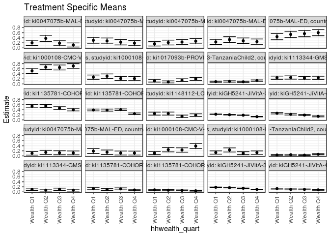

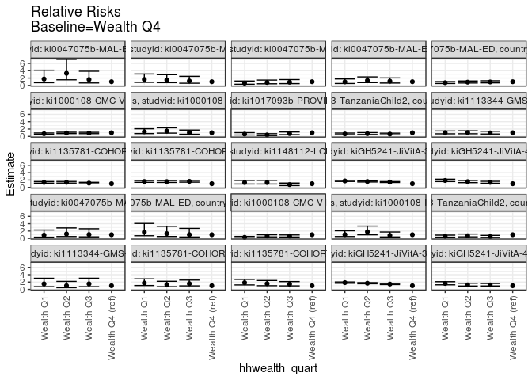

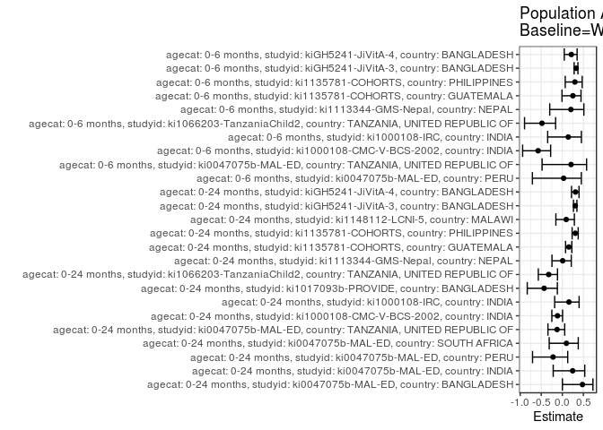

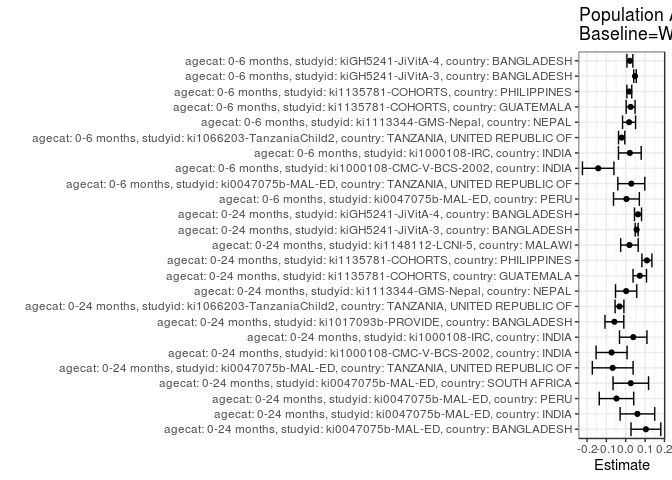

## Results Table

### Parameter: TSM

| agecat | studyid | country | intervention_level | baseline_level | estimate | ci_lower | ci_upper |
| --- | --- | --- | --- | --- | --- | --- | --- |
| 0-24 months | ki0047075b-MAL-ED | BANGLADESH | Wealth Q4 | NA | 0.1147541 | 0.0346050 | 0.1949032 |
| 0-24 months | ki0047075b-MAL-ED | BANGLADESH | Wealth Q1 | NA | 0.2000000 | 0.0985781 | 0.3014219 |
| 0-24 months | ki0047075b-MAL-ED | BANGLADESH | Wealth Q2 | NA | 0.3770492 | 0.2551760 | 0.4989224 |
| 0-24 months | ki0047075b-MAL-ED | BANGLADESH | Wealth Q3 | NA | 0.1833333 | 0.0852230 | 0.2814437 |
| 0-24 months | ki0047075b-MAL-ED | INDIA | Wealth Q4 | NA | 0.1864407 | 0.0868513 | 0.2860301 |
| 0-24 months | ki0047075b-MAL-ED | INDIA | Wealth Q1 | NA | 0.3000000 | 0.1837995 | 0.4162005 |
| 0-24 months | ki0047075b-MAL-ED | INDIA | Wealth Q2 | NA | 0.2758621 | 0.1605920 | 0.3911322 |
| 0-24 months | ki0047075b-MAL-ED | INDIA | Wealth Q3 | NA | 0.2241379 | 0.1165880 | 0.3316878 |
| 0-24 months | ki0047075b-MAL-ED | PERU | Wealth Q4 | NA | 0.2647059 | 0.1596535 | 0.3697582 |
| 0-24 months | ki0047075b-MAL-ED | PERU | Wealth Q1 | NA | 0.1617647 | 0.0740811 | 0.2494483 |
| 0-24 months | ki0047075b-MAL-ED | PERU | Wealth Q2 | NA | 0.2112676 | 0.1161414 | 0.3063938 |
| 0-24 months | ki0047075b-MAL-ED | PERU | Wealth Q3 | NA | 0.2307692 | 0.1281548 | 0.3333837 |
| 0-24 months | ki0047075b-MAL-ED | SOUTH AFRICA | Wealth Q4 | NA | 0.2461538 | 0.1412280 | 0.3510797 |
| 0-24 months | ki0047075b-MAL-ED | SOUTH AFRICA | Wealth Q1 | NA | 0.2343750 | 0.1303906 | 0.3383594 |
| 0-24 months | ki0047075b-MAL-ED | SOUTH AFRICA | Wealth Q2 | NA | 0.3281250 | 0.2128677 | 0.4433823 |
| 0-24 months | ki0047075b-MAL-ED | SOUTH AFRICA | Wealth Q3 | NA | 0.2812500 | 0.1708828 | 0.3916172 |
| 0-24 months | ki0047075b-MAL-ED | TANZANIA, UNITED REPUBLIC OF | Wealth Q4 | NA | 0.6031746 | 0.4821233 | 0.7242259 |
| 0-24 months | ki0047075b-MAL-ED | TANZANIA, UNITED REPUBLIC OF | Wealth Q1 | NA | 0.4444444 | 0.3214967 | 0.5673922 |
| 0-24 months | ki0047075b-MAL-ED | TANZANIA, UNITED REPUBLIC OF | Wealth Q2 | NA | 0.5322581 | 0.4078104 | 0.6567058 |
| 0-24 months | ki0047075b-MAL-ED | TANZANIA, UNITED REPUBLIC OF | Wealth Q3 | NA | 0.5645161 | 0.4408511 | 0.6881811 |
| 0-24 months | ki1000108-CMC-V-BCS-2002 | INDIA | Wealth Q4 | NA | 0.7083333 | 0.6172880 | 0.7993787 |
| 0-24 months | ki1000108-CMC-V-BCS-2002 | INDIA | Wealth Q1 | NA | 0.5164835 | 0.4136714 | 0.6192956 |
| 0-24 months | ki1000108-CMC-V-BCS-2002 | INDIA | Wealth Q2 | NA | 0.6631579 | 0.5679899 | 0.7583259 |
| 0-24 months | ki1000108-CMC-V-BCS-2002 | INDIA | Wealth Q3 | NA | 0.6483516 | 0.5501158 | 0.7465875 |
| 0-24 months | ki1000108-IRC | INDIA | Wealth Q4 | NA | 0.2100000 | 0.1300715 | 0.2899285 |
| 0-24 months | ki1000108-IRC | INDIA | Wealth Q1 | NA | 0.2666667 | 0.1819793 | 0.3513541 |
| 0-24 months | ki1000108-IRC | INDIA | Wealth Q2 | NA | 0.3039216 | 0.2145523 | 0.3932908 |
| 0-24 months | ki1000108-IRC | INDIA | Wealth Q3 | NA | 0.2135922 | 0.1343464 | 0.2928381 |
| 0-24 months | ki1017093b-PROVIDE | BANGLADESH | Wealth Q4 | NA | 0.1942857 | 0.1356246 | 0.2529468 |
| 0-24 months | ki1017093b-PROVIDE | BANGLADESH | Wealth Q1 | NA | 0.1206897 | 0.0722512 | 0.1691281 |

[output cut: 70 more lines]

### Parameter: E(Y)

| agecat | studyid | country | intervention_level | baseline_level | estimate | ci_lower | ci_upper |
| --- | --- | --- | --- | --- | --- | --- | --- |
| 0-24 months | ki0047075b-MAL-ED | BANGLADESH | NA | NA | 0.2190083 | 0.1667935 | 0.2712230 |
| 0-24 months | ki0047075b-MAL-ED | INDIA | NA | NA | 0.2468085 | 0.1915661 | 0.3020510 |
| 0-24 months | ki0047075b-MAL-ED | PERU | NA | NA | 0.2169118 | 0.1678424 | 0.2659811 |
| 0-24 months | ki0047075b-MAL-ED | SOUTH AFRICA | NA | NA | 0.2723735 | 0.2178399 | 0.3269072 |
| 0-24 months | ki0047075b-MAL-ED | TANZANIA, UNITED REPUBLIC OF | NA | NA | 0.5360000 | 0.4740573 | 0.5979427 |
| 0-24 months | ki1000108-CMC-V-BCS-2002 | INDIA | NA | NA | 0.6353887 | 0.5864772 | 0.6843003 |
| 0-24 months | ki1000108-IRC | INDIA | NA | NA | 0.2487805 | 0.2068840 | 0.2906770 |
| 0-24 months | ki1017093b-PROVIDE | BANGLADESH | NA | NA | 0.1357143 | 0.1103250 | 0.1611036 |
| 0-24 months | ki1066203-TanzaniaChild2 | TANZANIA, UNITED REPUBLIC OF | NA | NA | 0.0994128 | 0.0873992 | 0.1114263 |
| 0-24 months | ki1113344-GMS-Nepal | NEPAL | NA | NA | 0.2421203 | 0.2103189 | 0.2739218 |
| 0-24 months | ki1135781-COHORTS | GUATEMALA | NA | NA | 0.4726135 | 0.4452311 | 0.4999958 |
| 0-24 months | ki1135781-COHORTS | PHILIPPINES | NA | NA | 0.3562316 | 0.3392530 | 0.3732102 |
| 0-24 months | ki1148112-LCNI-5 | MALAWI | NA | NA | 0.2080783 | 0.1802263 | 0.2359304 |
| 0-24 months | kiGH5241-JiVitA-3 | BANGLADESH | NA | NA | 0.1845385 | 0.1789329 | 0.1901441 |
| 0-24 months | kiGH5241-JiVitA-4 | BANGLADESH | NA | NA | 0.2034648 | 0.1916516 | 0.2152780 |
| 0-6 months | ki0047075b-MAL-ED | PERU | NA | NA | 0.1213235 | 0.0824503 | 0.1601967 |
| 0-6 months | ki0047075b-MAL-ED | TANZANIA, UNITED REPUBLIC OF | NA | NA | 0.1400000 | 0.0969015 | 0.1830985 |
| 0-6 months | ki1000108-CMC-V-BCS-2002 | INDIA | NA | NA | 0.2472826 | 0.2031431 | 0.2914222 |
| 0-6 months | ki1000108-IRC | INDIA | NA | NA | 0.1512195 | 0.1164988 | 0.1859402 |
| 0-6 months | ki1066203-TanzaniaChild2 | TANZANIA, UNITED REPUBLIC OF | NA | NA | 0.0432047 | 0.0350415 | 0.0513679 |
| 0-6 months | ki1113344-GMS-Nepal | NEPAL | NA | NA | 0.0859599 | 0.0651504 | 0.1067694 |
| 0-6 months | ki1135781-COHORTS | GUATEMALA | NA | NA | 0.1012536 | 0.0828843 | 0.1196229 |
| 0-6 months | ki1135781-COHORTS | PHILIPPINES | NA | NA | 0.0624796 | 0.0538987 | 0.0710604 |
| 0-6 months | kiGH5241-JiVitA-3 | BANGLADESH | NA | NA | 0.1474739 | 0.1424227 | 0.1525252 |
| 0-6 months | kiGH5241-JiVitA-4 | BANGLADESH | NA | NA | 0.1014266 | 0.0924810 | 0.1103722 |

### Parameter: RR

| agecat | studyid | country | intervention_level | baseline_level | estimate | ci_lower | ci_upper |
| --- | --- | --- | --- | --- | --- | --- | --- |
| 0-24 months | ki0047075b-MAL-ED | BANGLADESH | Wealth Q4 | Wealth Q4 | 1.0000000 | 1.0000000 | 1.0000000 |
| 0-24 months | ki0047075b-MAL-ED | BANGLADESH | Wealth Q1 | Wealth Q4 | 1.7428571 | 0.7352116 | 4.1315329 |
| 0-24 months | ki0047075b-MAL-ED | BANGLADESH | Wealth Q2 | Wealth Q4 | 3.2857143 | 1.5219238 | 7.0935998 |
| 0-24 months | ki0047075b-MAL-ED | BANGLADESH | Wealth Q3 | Wealth Q4 | 1.5976190 | 0.6627391 | 3.8512693 |
| 0-24 months | ki0047075b-MAL-ED | INDIA | Wealth Q4 | Wealth Q4 | 1.0000000 | 1.0000000 | 1.0000000 |
| 0-24 months | ki0047075b-MAL-ED | INDIA | Wealth Q1 | Wealth Q4 | 1.6090909 | 0.8318141 | 3.1126829 |
| 0-24 months | ki0047075b-MAL-ED | INDIA | Wealth Q2 | Wealth Q4 | 1.4796238 | 0.7509669 | 2.9152906 |
| 0-24 months | ki0047075b-MAL-ED | INDIA | Wealth Q3 | Wealth Q4 | 1.2021944 | 0.5863224 | 2.4649770 |
| 0-24 months | ki0047075b-MAL-ED | PERU | Wealth Q4 | Wealth Q4 | 1.0000000 | 1.0000000 | 1.0000000 |
| 0-24 months | ki0047075b-MAL-ED | PERU | Wealth Q1 | Wealth Q4 | 0.6111111 | 0.3121489 | 1.1964058 |
| 0-24 months | ki0047075b-MAL-ED | PERU | Wealth Q2 | Wealth Q4 | 0.7981221 | 0.4379315 | 1.4545628 |
| 0-24 months | ki0047075b-MAL-ED | PERU | Wealth Q3 | Wealth Q4 | 0.8717949 | 0.4803647 | 1.5821860 |
| 0-24 months | ki0047075b-MAL-ED | SOUTH AFRICA | Wealth Q4 | Wealth Q4 | 1.0000000 | 1.0000000 | 1.0000000 |
| 0-24 months | ki0047075b-MAL-ED | SOUTH AFRICA | Wealth Q1 | Wealth Q4 | 0.9521484 | 0.5146389 | 1.7615975 |
| 0-24 months | ki0047075b-MAL-ED | SOUTH AFRICA | Wealth Q2 | Wealth Q4 | 1.3330078 | 0.7672788 | 2.3158594 |
| 0-24 months | ki0047075b-MAL-ED | SOUTH AFRICA | Wealth Q3 | Wealth Q4 | 1.1425781 | 0.6401197 | 2.0394384 |
| 0-24 months | ki0047075b-MAL-ED | TANZANIA, UNITED REPUBLIC OF | Wealth Q4 | Wealth Q4 | 1.0000000 | 1.0000000 | 1.0000000 |
| 0-24 months | ki0047075b-MAL-ED | TANZANIA, UNITED REPUBLIC OF | Wealth Q1 | Wealth Q4 | 0.7368421 | 0.5235384 | 1.0370515 |
| 0-24 months | ki0047075b-MAL-ED | TANZANIA, UNITED REPUBLIC OF | Wealth Q2 | Wealth Q4 | 0.8824278 | 0.6484254 | 1.2008765 |
| 0-24 months | ki0047075b-MAL-ED | TANZANIA, UNITED REPUBLIC OF | Wealth Q3 | Wealth Q4 | 0.9359083 | 0.6953549 | 1.2596795 |
| 0-24 months | ki1000108-CMC-V-BCS-2002 | INDIA | Wealth Q4 | Wealth Q4 | 1.0000000 | 1.0000000 | 1.0000000 |
| 0-24 months | ki1000108-CMC-V-BCS-2002 | INDIA | Wealth Q1 | Wealth Q4 | 0.7291532 | 0.5753226 | 0.9241153 |
| 0-24 months | ki1000108-CMC-V-BCS-2002 | INDIA | Wealth Q2 | Wealth Q4 | 0.9362229 | 0.7721662 | 1.1351356 |
| 0-24 months | ki1000108-CMC-V-BCS-2002 | INDIA | Wealth Q3 | Wealth Q4 | 0.9153200 | 0.7503818 | 1.1165125 |
| 0-24 months | ki1000108-IRC | INDIA | Wealth Q4 | Wealth Q4 | 1.0000000 | 1.0000000 | 1.0000000 |
| 0-24 months | ki1000108-IRC | INDIA | Wealth Q1 | Wealth Q4 | 1.2698413 | 0.7735147 | 2.0846363 |
| 0-24 months | ki1000108-IRC | INDIA | Wealth Q2 | Wealth Q4 | 1.4472456 | 0.8946626 | 2.3411282 |
| 0-24 months | ki1000108-IRC | INDIA | Wealth Q3 | Wealth Q4 | 1.0171059 | 0.5977622 | 1.7306285 |
| 0-24 months | ki1017093b-PROVIDE | BANGLADESH | Wealth Q4 | Wealth Q4 | 1.0000000 | 1.0000000 | 1.0000000 |
| 0-24 months | ki1017093b-PROVIDE | BANGLADESH | Wealth Q1 | Wealth Q4 | 0.6211968 | 0.3759328 | 1.0264745 |

[output cut: 70 more lines]

### Parameter: PAR

| agecat | studyid | country | intervention_level | baseline_level | estimate | ci_lower | ci_upper |
| --- | --- | --- | --- | --- | --- | --- | --- |
| 0-24 months | ki0047075b-MAL-ED | BANGLADESH | Wealth Q4 | NA | 0.1042542 | 0.0273661 | 0.1811422 |
| 0-24 months | ki0047075b-MAL-ED | INDIA | Wealth Q4 | NA | 0.0603678 | -0.0290170 | 0.1497527 |
| 0-24 months | ki0047075b-MAL-ED | PERU | Wealth Q4 | NA | -0.0477941 | -0.1368211 | 0.0412328 |
| 0-24 months | ki0047075b-MAL-ED | SOUTH AFRICA | Wealth Q4 | NA | 0.0262197 | -0.0655103 | 0.1179497 |
| 0-24 months | ki0047075b-MAL-ED | TANZANIA, UNITED REPUBLIC OF | Wealth Q4 | NA | -0.0671746 | -0.1725548 | 0.0382056 |
| 0-24 months | ki1000108-CMC-V-BCS-2002 | INDIA | Wealth Q4 | NA | -0.0729446 | -0.1530367 | 0.0071475 |
| 0-24 months | ki1000108-IRC | INDIA | Wealth Q4 | NA | 0.0387805 | -0.0321244 | 0.1096854 |
| 0-24 months | ki1017093b-PROVIDE | BANGLADESH | Wealth Q4 | NA | -0.0585714 | -0.1072046 | -0.0099383 |
| 0-24 months | ki1066203-TanzaniaChild2 | TANZANIA, UNITED REPUBLIC OF | Wealth Q4 | NA | -0.0321218 | -0.0548450 | -0.0093986 |
| 0-24 months | ki1113344-GMS-Nepal | NEPAL | Wealth Q4 | NA | 0.0021203 | -0.0527469 | 0.0569876 |
| 0-24 months | ki1135781-COHORTS | GUATEMALA | Wealth Q4 | NA | 0.0726135 | 0.0378532 | 0.1073737 |
| 0-24 months | ki1135781-COHORTS | PHILIPPINES | Wealth Q4 | NA | 0.1094938 | 0.0836436 | 0.1353439 |
| 0-24 months | ki1148112-LCNI-5 | MALAWI | Wealth Q4 | NA | 0.0191382 | -0.0261278 | 0.0644043 |
| 0-24 months | kiGH5241-JiVitA-3 | BANGLADESH | Wealth Q4 | NA | 0.0564122 | 0.0489392 | 0.0638852 |
| 0-24 months | kiGH5241-JiVitA-4 | BANGLADESH | Wealth Q4 | NA | 0.0634648 | 0.0452534 | 0.0816762 |
| 0-6 months | ki0047075b-MAL-ED | PERU | Wealth Q4 | NA | 0.0036765 | -0.0630623 | 0.0704152 |
| 0-6 months | ki0047075b-MAL-ED | TANZANIA, UNITED REPUBLIC OF | Wealth Q4 | NA | 0.0288889 | -0.0407999 | 0.0985776 |
| 0-6 months | ki1000108-CMC-V-BCS-2002 | INDIA | Wealth Q4 | NA | -0.1421911 | -0.2235039 | -0.0608783 |
| 0-6 months | ki1000108-IRC | INDIA | Wealth Q4 | NA | 0.0212195 | -0.0374004 | 0.0798394 |
| 0-6 months | ki1066203-TanzaniaChild2 | TANZANIA, UNITED REPUBLIC OF | Wealth Q4 | NA | -0.0208762 | -0.0370613 | -0.0046912 |
| 0-6 months | ki1113344-GMS-Nepal | NEPAL | Wealth Q4 | NA | 0.0173885 | -0.0162721 | 0.0510490 |
| 0-6 months | ki1135781-COHORTS | GUATEMALA | Wealth Q4 | NA | 0.0253374 | 0.0024609 | 0.0482138 |
| 0-6 months | ki1135781-COHORTS | PHILIPPINES | Wealth Q4 | NA | 0.0185887 | 0.0059625 | 0.0312149 |
| 0-6 months | kiGH5241-JiVitA-3 | BANGLADESH | Wealth Q4 | NA | 0.0480489 | 0.0414729 | 0.0546248 |
| 0-6 months | kiGH5241-JiVitA-4 | BANGLADESH | Wealth Q4 | NA | 0.0215519 | 0.0062301 | 0.0368737 |

### Parameter: PAF

| agecat | studyid | country | intervention_level | baseline_level | estimate | ci_lower | ci_upper |
| --- | --- | --- | --- | --- | --- | --- | --- |
| 0-24 months | ki0047075b-MAL-ED | BANGLADESH | Wealth Q4 | NA | 0.4760285 | 0.0014882 | 0.7250446 |
| 0-24 months | ki0047075b-MAL-ED | INDIA | Wealth Q4 | NA | 0.2445938 | -0.2167145 | 0.5310005 |
| 0-24 months | ki0047075b-MAL-ED | PERU | Wealth Q4 | NA | -0.2203390 | -0.7068479 | 0.1274986 |
| 0-24 months | ki0047075b-MAL-ED | SOUTH AFRICA | Wealth Q4 | NA | 0.0962637 | -0.3115870 | 0.3772893 |
| 0-24 months | ki0047075b-MAL-ED | TANZANIA, UNITED REPUBLIC OF | Wealth Q4 | NA | -0.1253258 | -0.3411650 | 0.0557776 |
| 0-24 months | ki1000108-CMC-V-BCS-2002 | INDIA | Wealth Q4 | NA | -0.1148031 | -0.2492557 | 0.0051789 |
| 0-24 months | ki1000108-IRC | INDIA | Wealth Q4 | NA | 0.1558824 | -0.1824009 | 0.3973832 |
| 0-24 months | ki1017093b-PROVIDE | BANGLADESH | Wealth Q4 | NA | -0.4315789 | -0.8323031 | -0.1184930 |
| 0-24 months | ki1066203-TanzaniaChild2 | TANZANIA, UNITED REPUBLIC OF | Wealth Q4 | NA | -0.3231157 | -0.5698034 | -0.1151938 |
| 0-24 months | ki1113344-GMS-Nepal | NEPAL | Wealth Q4 | NA | 0.0087574 | -0.2458479 | 0.2113308 |
| 0-24 months | ki1135781-COHORTS | GUATEMALA | Wealth Q4 | NA | 0.1536424 | 0.0764998 | 0.2243411 |
| 0-24 months | ki1135781-COHORTS | PHILIPPINES | Wealth Q4 | NA | 0.3073668 | 0.2312478 | 0.3759487 |
| 0-24 months | ki1148112-LCNI-5 | MALAWI | Wealth Q4 | NA | 0.0919761 | -0.1536068 | 0.2852787 |
| 0-24 months | kiGH5241-JiVitA-3 | BANGLADESH | Wealth Q4 | NA | 0.3056932 | 0.2637078 | 0.3452846 |
| 0-24 months | kiGH5241-JiVitA-4 | BANGLADESH | Wealth Q4 | NA | 0.3119203 | 0.2172287 | 0.3951571 |
| 0-6 months | ki0047075b-MAL-ED | PERU | Wealth Q4 | NA | 0.0303030 | -0.7099137 | 0.4500821 |
| 0-6 months | ki0047075b-MAL-ED | TANZANIA, UNITED REPUBLIC OF | Wealth Q4 | NA | 0.2063492 | -0.4803640 | 0.5745090 |
| 0-6 months | ki1000108-CMC-V-BCS-2002 | INDIA | Wealth Q4 | NA | -0.5750145 | -0.9413714 | -0.2777929 |
| 0-6 months | ki1000108-IRC | INDIA | Wealth Q4 | NA | 0.1403226 | -0.3480279 | 0.4517582 |
| 0-6 months | ki1066203-TanzaniaChild2 | TANZANIA, UNITED REPUBLIC OF | Wealth Q4 | NA | -0.4831939 | -0.8968376 | -0.1597535 |
| 0-6 months | ki1113344-GMS-Nepal | NEPAL | Wealth Q4 | NA | 0.2022857 | -0.2990138 | 0.5101299 |
| 0-6 months | ki1135781-COHORTS | GUATEMALA | Wealth Q4 | NA | 0.2502368 | -0.0082753 | 0.4424690 |
| 0-6 months | ki1135781-COHORTS | PHILIPPINES | Wealth Q4 | NA | 0.2975163 | 0.0683899 | 0.4702899 |
| 0-6 months | kiGH5241-JiVitA-3 | BANGLADESH | Wealth Q4 | NA | 0.3258127 | 0.2798310 | 0.3688586 |
| 0-6 months | kiGH5241-JiVitA-4 | BANGLADESH | Wealth Q4 | NA | 0.2124877 | 0.0458187 | 0.3500443 |